# Week 4: Factor Analysis

October 2, 2018

## Roadmap - Factor Analysis (FA)

- Review Efficacy Items
- Why Factor Analysis?
- Factor Anaysis versus Classical Test Theory
- FA versus Principal Components Analysis
- Number of Factors, Extraction, and Rotation

## Teacher Efficacy Items

Our previous analysis suggested that 'force of motivation' for program implementation may vary from 'force of motivation' for subject instruction, suggesting two dimensions of 'force of motivation'.

## Teacher Efficacy Items

- ELA and Math
  - Most Students can learn what I am supposed to teach (*Expectancy*)
  - By trying different methods, I can affect achievement (*Efficacy*)
  - I feel satisfaction when students learn (*Value*)
- Program
  - I am capable of making changes called by by the program (*Efficacy*)
  - The changes called for by the program help my students achieve (*Expectancy*)
  - I value changes called for by program (*Value*)

## Why Factor Analysis?

- Often we want to measure something, but cannot directly observe it
  - e.g. teacher efficacy
- In this case, we can
  - Theoretically postulated the existence of the latent construct
  - Design items capturing 'observable' characteristics influenced by the latent construct
  - Infer a score for the latent construct based on responses to items related to that construct
- Factor Analysis addresses the questions:
  - Is there empirical evidence for the hypothesized construct?
  - Are there additional constructs that also influence scores on many items?

## Domain Sampling

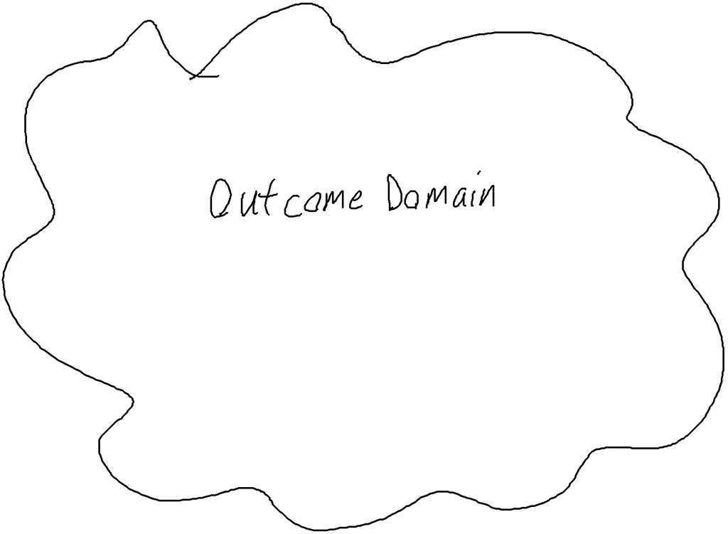

## Domain Sampling

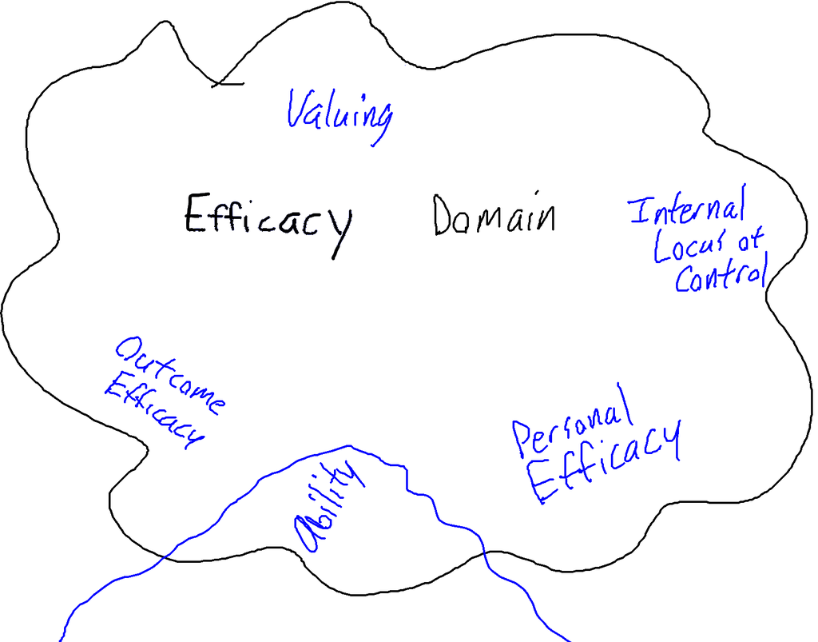

## CTT vs FA

Classical Test Theory:

\[ X_i=T+E_i \]

Factor Analysis:

\[ X_i=\mu_i+\sum_j^J{\lambda_i*F_j}+E_i \]

\(\Longrightarrow\)

\[ T \equiv \mu_i+\sum_j^J{\lambda_i*F_j} \]

- Errors Remain Same
- If all items have same mean (\(\mu_i=\mu\)), there is one factor (\(J=1\)), and all loadings are 1 (\(\lambda_i=1\)), models are equivalent.
- FA as relaxing assumptions of CTT

## Factor Structure

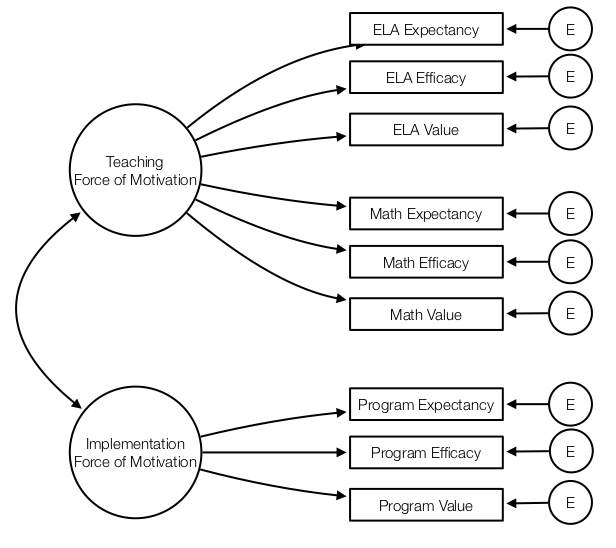

## FA versus PCA

Imagine we observe two highly correlated variables as shown to the right. What does PCA do?

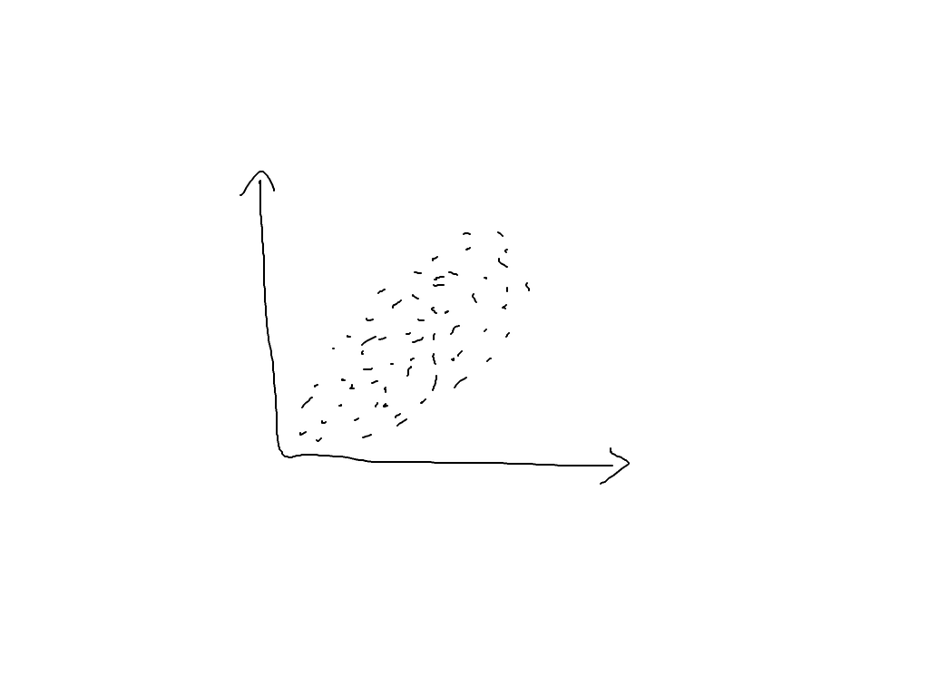

## FA versus PCA

PCA simply tilts axes. Instead of having axes X<sub>1</sub> and X<sub>2</sub>, we get axes PCA<sub>1</sub> and PCA<sub>2</sub>. We can then choose to only use PCA<sub>1</sub> to represent the data (with some loss of information). There is no mathematical model, no way of determining fit to a model, and no characterization of the error of measurement.

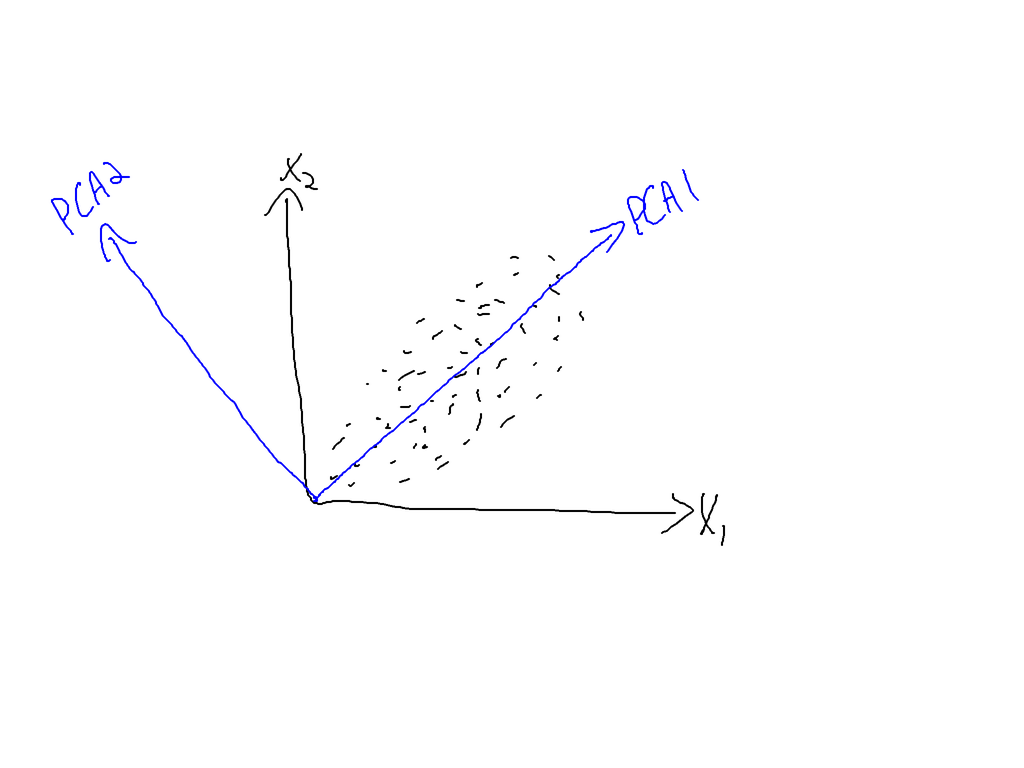

## Number of Factors

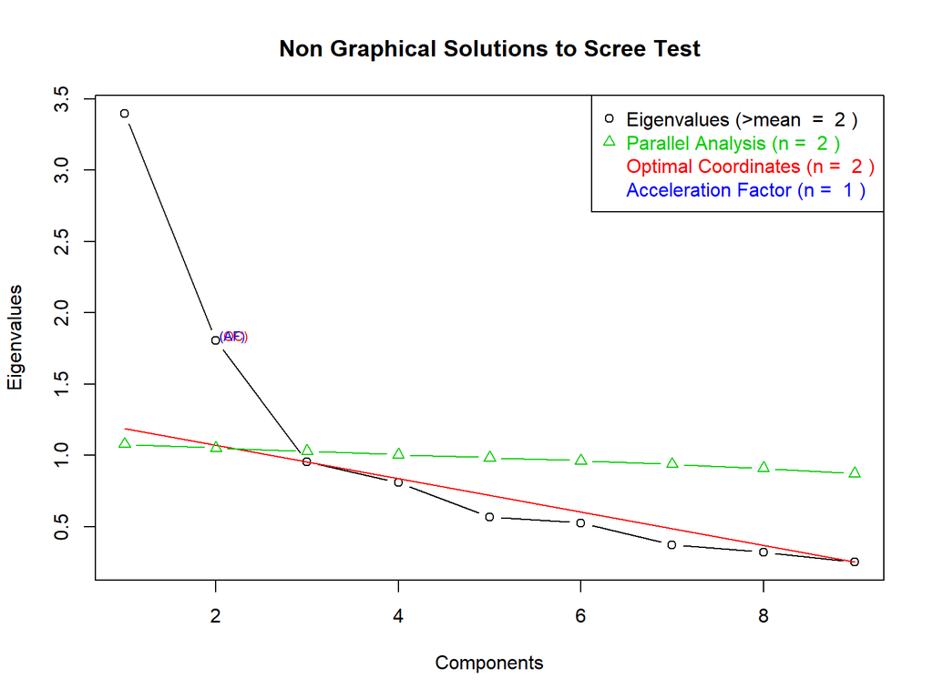

## Missing Data Concerns

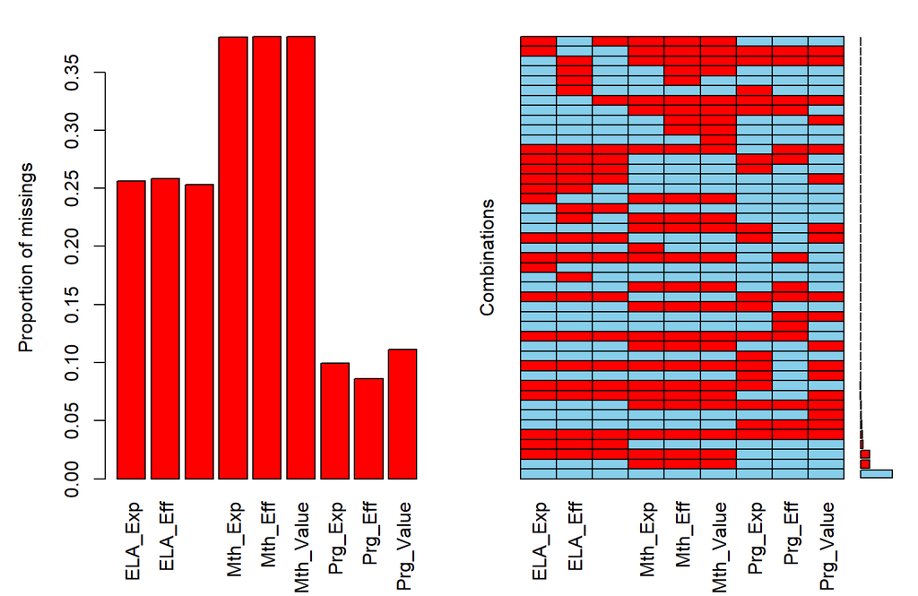

## Sample Size

- Full Sample: 1994
- Rows with All Data: 1018
- Average Pairwise Sample:
  - ELA-Math: 1128.3237
  - ELA-Prog: 1379.8918
  - Math-Prog: 1160.3394

## Factor Analysis

```r
FA<-fa(qgraph::cor_auto(FactVars),
   n.obs=nrow(FactVars),
   nfactors=2,
   rotate="none",
   fm="minres",
   n.iter=5)
```

- cor_auto - polychoric correlations
- MinRes - similar to ML, but robust
- No Rotation
- n.iter - get SD through bootstrap

## Factor Analysis

Variance Explained by Two Factors:

```
##                          MR1    MR2
## SS loadings           3.0635 1.5006
## Proportion Var        0.3404 0.1667
## Cumulative Var        0.3404 0.5071
## Proportion Explained  0.6712 0.3288
## Cumulative Proportion 0.6712 1.0000
```

## Factor Loadings (no rotation)

|  | F<sub>1</sub> | SE<sub>1</sub> | F<sub>2</sub> | SE<sub>2</sub> | Uniqness | Communality |
| --- | --- | --- | --- | --- | --- | --- |
| ELA_Exp | 0.59 | 0.01 | 0.20 | 0.02 | 0.62 | 0.38 |
| ELA_Eff | 0.59 | 0.01 | 0.28 | 0.03 | 0.57 | 0.43 |
| ELA_Value | 0.44 | 0.01 | 0.32 | 0.02 | 0.69 | 0.31 |
| Mth_Exp | 0.62 | 0.01 | 0.29 | 0.02 | 0.54 | 0.46 |
| Mth_Eff | 0.63 | 0.01 | 0.40 | 0.01 | 0.45 | 0.55 |
| Mth_Value | 0.44 | 0.01 | 0.39 | 0.03 | 0.66 | 0.34 |
| Prg_Exp | 0.71 | 0.01 | -0.59 | 0.01 | 0.16 | 0.84 |
| Prg_Eff | 0.58 | 0.02 | -0.43 | 0.02 | 0.47 | 0.53 |
| Prg_Value | 0.63 | 0.00 | -0.56 | 0.01 | 0.28 | 0.72 |

## Oblimin Rotation

[output not shown]

## Factor Structure

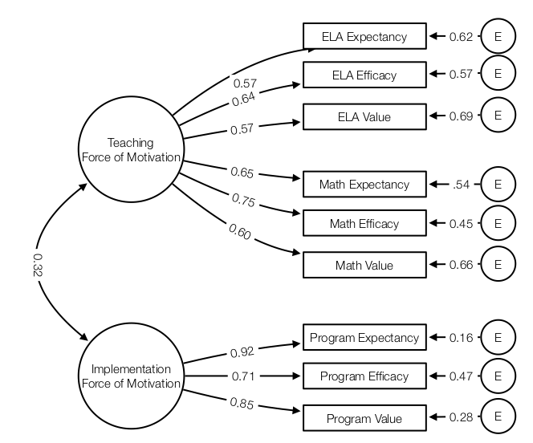

## Change in True Score Across Time

Note that

- Variance of the Error Doubles in Difference
- Variance of \(T_\delta\) is usually less than variance in \(T\)
  - Hence, true score decreases
- Thus, reliability decreases greatly when examining change in true score across time